# Apriori algorithm: small example

We will use the `arules` package to generate association rules and the `arulesViz` package to visualize them.

```r
library(arules)
library(arulesViz)
library(tidyverse)
```

Documentation on the `arules` and `arulesViz` packages can be found here:

https://cran.r-project.org/web/packages/arules/vignettes/arules.pdf

https://cran.r-project.org/web/packages/arulesViz/vignettes/arulesViz.pdf

## Example 1

In this example we will define the **transaction** from a *list* object:

```r
# define lists
shopping_list <- list(
  c("flowers", "card", "soda"),
  c("toy", "flowers", "balloons", "candy"),
  c("card", "candy", "flowers"),
  c("toy", "balloons", "soda"),
  c("flowers", "card", "soda")
)
```

We now change the class of the list into a *transactions* class object (the `transactions` class represents transaction data used for mining itemsets or rules):

```r
# coerce as transaction
shopping_tr <- as(shopping_list, "transactions")
```

The apriori algorithm is used below to generate rules from our shopping list:

```r
# uses the apriori() function
shopping_rules <- apriori(shopping_tr,
                          parameter = list(support = 0.1,
                                           confidence = 0.25,
                                           minlen = 2))
```

```
## Apriori
##
## Parameter specification:
##  confidence minval smax arem  aval originalSupport maxtime support minlen
##        0.25    0.1    1 none FALSE            TRUE       5     0.1      2
##  maxlen target  ext
##      10  rules TRUE
##
## Algorithmic control:
##  filter tree heap memopt load sort verbose
##     0.1 TRUE TRUE  FALSE TRUE    2    TRUE
##
## Absolute minimum support count: 0
##
## set item appearances ...[0 item(s)] done [0.00s].
## set transactions ...[6 item(s), 5 transaction(s)] done [0.00s].
## sorting and recoding items ... [6 item(s)] done [0.00s].
## creating transaction tree ... done [0.00s].
## checking subsets of size 1 2 3 4 done [0.00s].
## writing ... [49 rule(s)] done [0.00s].
## creating S4 object  ... done [0.00s].
```

We use the `inspect()` function to check the top 3 rules based on *confidence*

```r
# inspect by confidence
inspect(head(sort(shopping_rules, by = "confidence"), 3))
```

```
##     lhs           rhs        support confidence coverage lift count
## [1] {balloons} => {toy}      0.4     1          0.4      2.50 2
## [2] {toy}      => {balloons} 0.4     1          0.4      2.50 2
## [3] {candy}    => {flowers}  0.4     1          0.4      1.25 2
```

```r
shopping_rules %>%
  sort( . , by = "confidence") %>%
  head(3) %>%
  inspect()
```

```
##     lhs           rhs        support confidence coverage lift count
## [1] {balloons} => {toy}      0.4     1          0.4      2.50 2
## [2] {toy}      => {balloons} 0.4     1          0.4      2.50 2
## [3] {candy}    => {flowers}  0.4     1          0.4      1.25 2
```

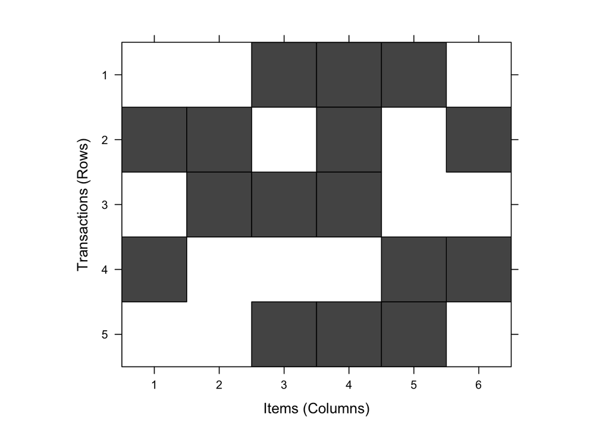

```r
image(shopping_tr)
```

## Example 2

In this example we create transactions from a data frame:

```r
## creating transactions from data.frame
students_df <- data.frame(
  age = factor(c(6, 8, NA, 9, 16)),
  grade = factor(c("A", "C", "F", NA, "C")),
  pass = c(TRUE, TRUE, FALSE, TRUE, TRUE)
)
```

Again, we *coerce* the data frame as a `transactions` object:

```r
## coerce
students_tr <- as(students_df, "transactions")
```

We can inspect this new object:

```r
# inspect
inspect(students_tr)
```

```
##     items                   transactionID
## [1] {age=6, grade=A, pass}  1
## [2] {age=8, grade=C, pass}  2
## [3] {grade=F}               3
## [4] {age=9, pass}           4
## [5] {age=16, grade=C, pass} 5
```

Below the apriori algorithm is used with its default values:

```r
students_rules <- apriori(students_tr)
```

```
## Apriori
##
## Parameter specification:
##  confidence minval smax arem  aval originalSupport maxtime support minlen
##         0.8    0.1    1 none FALSE            TRUE       5     0.1      1
##  maxlen target  ext
##      10  rules TRUE
##
## Algorithmic control:
##  filter tree heap memopt load sort verbose
##     0.1 TRUE TRUE  FALSE TRUE    2    TRUE
##
## Absolute minimum support count: 0
##
## set item appearances ...[0 item(s)] done [0.00s].
## set transactions ...[8 item(s), 5 transaction(s)] done [0.00s].
## sorting and recoding items ... [8 item(s)] done [0.00s].
## creating transaction tree ... done [0.00s].
## checking subsets of size 1 2 3 done [0.00s].
## writing ... [18 rule(s)] done [0.00s].
## creating S4 object  ... done [0.00s].
```

Let us inspect the generated rules this time based on the top 6 rules by *lift*:

```r
students_rules %>%
  sort( . , by = "lift") %>%
  head(6) %>%
  inspect()
```

```
##     lhs                rhs       support confidence coverage lift count
## [1] {grade=A}       => {age=6}   0.2     1          0.2      5.0  1
## [2] {age=6}         => {grade=A} 0.2     1          0.2      5.0  1
## [3] {grade=A, pass} => {age=6}   0.2     1          0.2      5.0  1
## [4] {age=6, pass}   => {grade=A} 0.2     1          0.2      5.0  1
## [5] {age=8}         => {grade=C} 0.2     1          0.2      2.5  1
## [6] {age=16}        => {grade=C} 0.2     1          0.2      2.5  1
```

## Example 3

First, let us create transactions from a list:

```r
publix <- list(
  c("milk", "tea", "cake"),
  c("eggs", "tea", "cold drink"),
  c("milk", "eggs", "tea", "cold drink"),
  c("eggs", "cold drink"),
  c("juice")
)
```

Convert list to transactions class:

```r
publix_tr <- as(publix, "transactions")
```

An item frequency plot can be created using the `itemFrequencyPlot()` function:

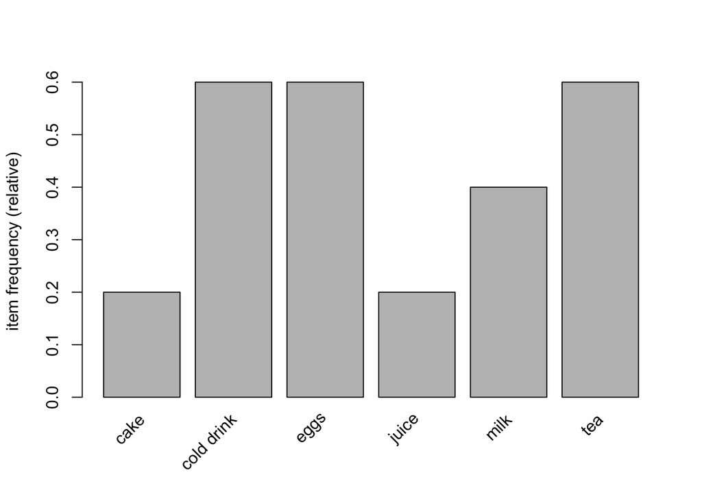

```r
itemFrequencyPlot(publix_tr)
```

Use apriori algorithm with support set to 0.4:

```r
publix_rules <- apriori(publix_tr,
                        parameter = list(support = 0.4))
```

```
## Apriori
##
## Parameter specification:
##  confidence minval smax arem  aval originalSupport maxtime support minlen
##         0.8    0.1    1 none FALSE            TRUE       5     0.4      1
##  maxlen target  ext
##      10  rules TRUE
##
## Algorithmic control:
##  filter tree heap memopt load sort verbose
##     0.1 TRUE TRUE  FALSE TRUE    2    TRUE
##
## Absolute minimum support count: 2
##
## set item appearances ...[0 item(s)] done [0.00s].
## set transactions ...[6 item(s), 5 transaction(s)] done [0.00s].
## sorting and recoding items ... [4 item(s)] done [0.00s].
## creating transaction tree ... done [0.00s].
## checking subsets of size 1 2 3 done [0.00s].
## writing ... [5 rule(s)] done [0.00s].
## creating S4 object  ... done [0.00s].
```

Inspect the rules:

```r
inspect(publix_rules)
```

```
##     lhs                  rhs          support confidence coverage lift
## [1] {milk}            => {tea}        0.4     1          0.4      1.666667
## [2] {cold drink}      => {eggs}       0.6     1          0.6      1.666667
## [3] {eggs}            => {cold drink} 0.6     1          0.6      1.666667
## [4] {cold drink, tea} => {eggs}       0.4     1          0.4      1.666667
## [5] {eggs, tea}       => {cold drink} 0.4     1          0.4      1.666667
##     count
## [1] 2
## [2] 3
## [3] 3
## [4] 2
## [5] 2
```

Let us visualize these rules using tools from the `arulesViz` package.

```r
plot(publix_rules, method = "graph", control = list(type = "items"),
     engine = "htmlwidget")
```

[output not shown]

[interactive chart not shown]